# Investigating TMDB dataset

## Introduction

The dataset we will use in this project is about movies, and because I watch a lot of movies every year, I have choose this dataset to work on. The data contains 10866 rows and 21 column here is some definetion for the columns

- Id , Imdb_id : a unique number for each movie
- popularity : a numerical value indicates how much popular is the movie
- cast: indicates the actors in each movie
- hompage: the website for each movie
- director: the director for the movie
- Tagline : the phrase that follows the name of the movie
- overview: a quick intro to the movie story
- runtime: the lenght of the movie in minutes
- genres : the category of the movie
- production_companies : the companies that produced the movie
- release_date : the release date of the movie.
- vote_count : number of voting for each movie
- vote_average : total average of user voting
- release_year : year of release for each movie

We will try to build our question based on revenue , vote average and date , and these are the questions that we will try to answer :

```
Q1- Who are the top dircetors in terms of revenue ?
Q2- Does the month affect revenue ?
Q3- What are the genres with highest number of movies?
Q4- Are the vote average increasing or decreasing overtime?
Q5- Does the budget affect the rating ?
```

```python
import numpy as np
import pandas as pd
import matplotlib.pyplot as plt
import seaborn as sns
%matplotlib inline
```

Here we will import the data , and use .head() to show the first five rows of our data

```python
#importing data
df = pd.read_csv('/Users/SulMac/Desktop/B.S in AI/Data Analyst/Project2/Data/tmdb-movies.csv')
#taking a look into our data
df.head()
```

|  | id | imdb_id | popularity | budget | revenue | original_title | cast | homepage | director | tagline | ... | overview | runtime | genres | production_companies | release_date | vote_count | vote_average | release_year | budget_adj | revenue_adj |
| --- | --- | --- | --- | --- | --- | --- | --- | --- | --- | --- | --- | --- | --- | --- | --- | --- | --- | --- | --- | --- | --- |
| 0 | 135397 | tt0369610 | 32.985763 | 150000000 | 1513528810 | Jurassic World | Chris Pratt\|Bryce Dallas Howard\|Irrfan Khan\|Vi... | http://www.jurassicworld.com/ | Colin Trevorrow | The park is open. | ... | Twenty-two years after the events of Jurassic ... | 124 | Action\|Adventure\|Science Fiction\|Thriller | Universal Studios\|Amblin Entertainment\|Legenda... | 6/9/15 | 5562 | 6.5 | 2015 | 1.379999e+08 | 1.392446e+09 |
| 1 | 76341 | tt1392190 | 28.419936 | 150000000 | 378436354 | Mad Max: Fury Road | Tom Hardy\|Charlize Theron\|Hugh Keays-Byrne\|Nic... | http://www.madmaxmovie.com/ | George Miller | What a Lovely Day. | ... | An apocalyptic story set in the furthest reach... | 120 | Action\|Adventure\|Science Fiction\|Thriller | Village Roadshow Pictures\|Kennedy Miller Produ... | 5/13/15 | 6185 | 7.1 | 2015 | 1.379999e+08 | 3.481613e+08 |
| 2 | 262500 | tt2908446 | 13.112507 | 110000000 | 295238201 | Insurgent | Shailene Woodley\|Theo James\|Kate Winslet\|Ansel... | http://www.thedivergentseries.movie/#insurgent | Robert Schwentke | One Choice Can Destroy You | ... | Beatrice Prior must confront her inner demons ... | 119 | Adventure\|Science Fiction\|Thriller | Summit Entertainment\|Mandeville Films\|Red Wago... | 3/18/15 | 2480 | 6.3 | 2015 | 1.012000e+08 | 2.716190e+08 |
| 3 | 140607 | tt2488496 | 11.173104 | 200000000 | 2068178225 | Star Wars: The Force Awakens | Harrison Ford\|Mark Hamill\|Carrie Fisher\|Adam D... | http://www.starwars.com/films/star-wars-episod... | J.J. Abrams | Every generation has a story. | ... | Thirty years after defeating the Galactic Empi... | 136 | Action\|Adventure\|Science Fiction\|Fantasy | Lucasfilm\|Truenorth Productions\|Bad Robot | 12/15/15 | 5292 | 7.5 | 2015 | 1.839999e+08 | 1.902723e+09 |
| 4 | 168259 | tt2820852 | 9.335014 | 190000000 | 1506249360 | Furious 7 | Vin Diesel\|Paul Walker\|Jason Statham\|Michelle ... | http://www.furious7.com/ | James Wan | Vengeance Hits Home | ... | Deckard Shaw seeks revenge against Dominic Tor... | 137 | Action\|Crime\|Thriller | Universal Pictures\|Original Film\|Media Rights ... | 4/1/15 | 2947 | 7.3 | 2015 | 1.747999e+08 | 1.385749e+09 |

5 rows × 21 columns

# Data Preprocessing

> Checking how many rows and cols we have

```python
df.shape
```

```
(10866, 21)
```

> Some statistical popular calculations , like mean, std, min and max ..etc

```python
df.describe()
```

|  | id | popularity | budget | revenue | runtime | vote_count | vote_average | release_year | budget_adj | revenue_adj |
| --- | --- | --- | --- | --- | --- | --- | --- | --- | --- | --- |
| count | 10866.000000 | 10866.000000 | 1.086600e+04 | 1.086600e+04 | 10866.000000 | 10866.000000 | 10866.000000 | 10866.000000 | 1.086600e+04 | 1.086600e+04 |
| mean | 66064.177434 | 0.646441 | 1.462570e+07 | 3.982332e+07 | 102.070863 | 217.389748 | 5.974922 | 2001.322658 | 1.755104e+07 | 5.136436e+07 |
| std | 92130.136561 | 1.000185 | 3.091321e+07 | 1.170035e+08 | 31.381405 | 575.619058 | 0.935142 | 12.812941 | 3.430616e+07 | 1.446325e+08 |
| min | 5.000000 | 0.000065 | 0.000000e+00 | 0.000000e+00 | 0.000000 | 10.000000 | 1.500000 | 1960.000000 | 0.000000e+00 | 0.000000e+00 |
| 25% | 10596.250000 | 0.207583 | 0.000000e+00 | 0.000000e+00 | 90.000000 | 17.000000 | 5.400000 | 1995.000000 | 0.000000e+00 | 0.000000e+00 |
| 50% | 20669.000000 | 0.383856 | 0.000000e+00 | 0.000000e+00 | 99.000000 | 38.000000 | 6.000000 | 2006.000000 | 0.000000e+00 | 0.000000e+00 |
| 75% | 75610.000000 | 0.713817 | 1.500000e+07 | 2.400000e+07 | 111.000000 | 145.750000 | 6.600000 | 2011.000000 | 2.085325e+07 | 3.369710e+07 |
| max | 417859.000000 | 32.985763 | 4.250000e+08 | 2.781506e+09 | 900.000000 | 9767.000000 | 9.200000 | 2015.000000 | 4.250000e+08 | 2.827124e+09 |

checking the types in our data We have 3 types in this data:

- integer(int64)
- float(float64)
- Strings (object)

```python
df.dtypes
```

```
id                        int64
imdb_id                  object
popularity              float64
budget                    int64
revenue                   int64
original_title           object
cast                     object
homepage                 object
director                 object
tagline                  object
keywords                 object
overview                 object
runtime                   int64
genres                   object
production_companies     object
release_date             object
vote_count                int64
vote_average            float64
release_year              int64
budget_adj              float64
revenue_adj             float64
dtype: object
```

Checking how many null values we have

```python
df.isna().count().sum()
```

```
228186
```

Checking how many duplicated values we have

```python
df.duplicated().count()
```

```
10866
```

```
array([[<AxesSubplot:title={'center':'id'}>,
        <AxesSubplot:title={'center':'popularity'}>,
        <AxesSubplot:title={'center':'budget'}>],
       [<AxesSubplot:title={'center':'revenue'}>,
        <AxesSubplot:title={'center':'runtime'}>,
        <AxesSubplot:title={'center':'vote_count'}>],
       [<AxesSubplot:title={'center':'vote_average'}>,
        <AxesSubplot:title={'center':'release_year'}>,
        <AxesSubplot:title={'center':'budget_adj'}>],
       [<AxesSubplot:title={'center':'revenue_adj'}>, <AxesSubplot:>,
        <AxesSubplot:>]], dtype=object)
```

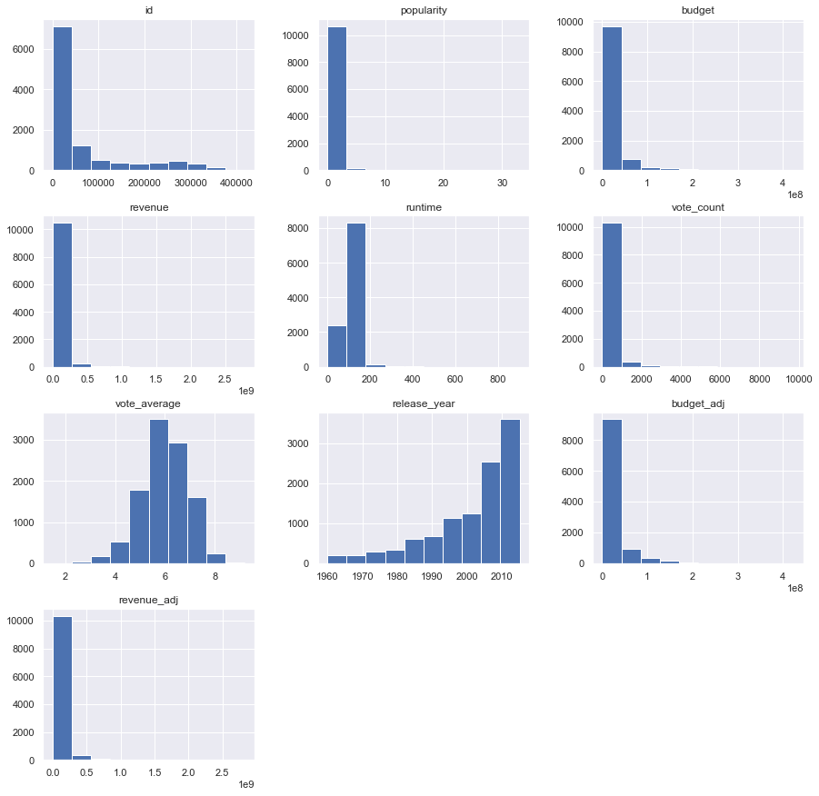

```python
df.hist(figsize=(15,15))
```

```python
#showing all columns we have to check which one we need and which one we will keep
df[df.columns]
```

|  | id | imdb_id | popularity | budget | revenue | original_title | cast | homepage | director | tagline | ... | overview | runtime | genres | production_companies | release_date | vote_count | vote_average | release_year | budget_adj | revenue_adj |
| --- | --- | --- | --- | --- | --- | --- | --- | --- | --- | --- | --- | --- | --- | --- | --- | --- | --- | --- | --- | --- | --- |
| 0 | 135397 | tt0369610 | 32.985763 | 150000000 | 1513528810 | Jurassic World | Chris Pratt\|Bryce Dallas Howard\|Irrfan Khan\|Vi... | http://www.jurassicworld.com/ | Colin Trevorrow | The park is open. | ... | Twenty-two years after the events of Jurassic ... | 124 | Action\|Adventure\|Science Fiction\|Thriller | Universal Studios\|Amblin Entertainment\|Legenda... | 6/9/15 | 5562 | 6.5 | 2015 | 1.379999e+08 | 1.392446e+09 |
| 1 | 76341 | tt1392190 | 28.419936 | 150000000 | 378436354 | Mad Max: Fury Road | Tom Hardy\|Charlize Theron\|Hugh Keays-Byrne\|Nic... | http://www.madmaxmovie.com/ | George Miller | What a Lovely Day. | ... | An apocalyptic story set in the furthest reach... | 120 | Action\|Adventure\|Science Fiction\|Thriller | Village Roadshow Pictures\|Kennedy Miller Produ... | 5/13/15 | 6185 | 7.1 | 2015 | 1.379999e+08 | 3.481613e+08 |
| 2 | 262500 | tt2908446 | 13.112507 | 110000000 | 295238201 | Insurgent | Shailene Woodley\|Theo James\|Kate Winslet\|Ansel... | http://www.thedivergentseries.movie/#insurgent | Robert Schwentke | One Choice Can Destroy You | ... | Beatrice Prior must confront her inner demons ... | 119 | Adventure\|Science Fiction\|Thriller | Summit Entertainment\|Mandeville Films\|Red Wago... | 3/18/15 | 2480 | 6.3 | 2015 | 1.012000e+08 | 2.716190e+08 |
| 3 | 140607 | tt2488496 | 11.173104 | 200000000 | 2068178225 | Star Wars: The Force Awakens | Harrison Ford\|Mark Hamill\|Carrie Fisher\|Adam D... | http://www.starwars.com/films/star-wars-episod... | J.J. Abrams | Every generation has a story. | ... | Thirty years after defeating the Galactic Empi... | 136 | Action\|Adventure\|Science Fiction\|Fantasy | Lucasfilm\|Truenorth Productions\|Bad Robot | 12/15/15 | 5292 | 7.5 | 2015 | 1.839999e+08 | 1.902723e+09 |
| 4 | 168259 | tt2820852 | 9.335014 | 190000000 | 1506249360 | Furious 7 | Vin Diesel\|Paul Walker\|Jason Statham\|Michelle ... | http://www.furious7.com/ | James Wan | Vengeance Hits Home | ... | Deckard Shaw seeks revenge against Dominic Tor... | 137 | Action\|Crime\|Thriller | Universal Pictures\|Original Film\|Media Rights ... | 4/1/15 | 2947 | 7.3 | 2015 | 1.747999e+08 | 1.385749e+09 |
| ... | ... | ... | ... | ... | ... | ... | ... | ... | ... | ... | ... | ... | ... | ... | ... | ... | ... | ... | ... | ... | ... |
| 10861 | 21 | tt0060371 | 0.080598 | 0 | 0 | The Endless Summer | Michael Hynson\|Robert August\|Lord 'Tally Ho' B... | NaN | Bruce Brown | NaN | ... | The Endless Summer, by Bruce Brown, is one of ... | 95 | Documentary | Bruce Brown Films | 6/15/66 | 11 | 7.4 | 1966 | 0.000000e+00 | 0.000000e+00 |
| 10862 | 20379 | tt0060472 | 0.065543 | 0 | 0 | Grand Prix | James Garner\|Eva Marie Saint\|Yves Montand\|Tosh... | NaN | John Frankenheimer | Cinerama sweeps YOU into a drama of speed and ... | ... | Grand Prix driver Pete Aron is fired by his te... | 176 | Action\|Adventure\|Drama | Cherokee Productions\|Joel Productions\|Douglas ... | 12/21/66 | 20 | 5.7 | 1966 | 0.000000e+00 | 0.000000e+00 |
| 10863 | 39768 | tt0060161 | 0.065141 | 0 | 0 | Beregis Avtomobilya | Innokentiy Smoktunovskiy\|Oleg Efremov\|Georgi Z... | NaN | Eldar Ryazanov | NaN | ... | An insurance agent who moonlights as a carthie... | 94 | Mystery\|Comedy | Mosfilm | 1/1/66 | 11 | 6.5 | 1966 | 0.000000e+00 | 0.000000e+00 |
| 10864 | 21449 | tt0061177 | 0.064317 | 0 | 0 | What's Up, Tiger Lily? | Tatsuya Mihashi\|Akiko Wakabayashi\|Mie Hama\|Joh... | NaN | Woody Allen | WOODY ALLEN STRIKES BACK! | ... | In comic Woody Allen's film debut, he took the... | 80 | Action\|Comedy | Benedict Pictures Corp. | 11/2/66 | 22 | 5.4 | 1966 | 0.000000e+00 | 0.000000e+00 |
| 10865 | 22293 | tt0060666 | 0.035919 | 19000 | 0 | Manos: The Hands of Fate | Harold P. Warren\|Tom Neyman\|John Reynolds\|Dian... | NaN | Harold P. Warren | It's Shocking! It's Beyond Your Imagination! | ... | A family gets lost on the road and stumbles up... | 74 | Horror | Norm-Iris | 11/15/66 | 15 | 1.5 | 1966 | 1.276423e+05 | 0.000000e+00 |

10866 rows × 21 columns

Dropping the columns that we don't need

```python
df.drop(['id','imdb_id','budget_adj','revenue_adj' , 'homepage','tagline','overview','production_companies','keywords'], axis=1, inplace=True)
```

```python
df.columns
```

```
Index(['popularity', 'budget', 'revenue', 'original_title', 'cast', 'director',
       'runtime', 'genres', 'release_date', 'vote_count', 'vote_average',
       'release_year'],
      dtype='object')
```

```python
#Dropping dups
df.drop_duplicates(inplace=True)
#Checking if there is any dups left
df.duplicated().sum()
```

```
0
```

As we can see the null vslues number are in 'cast' , 'genres' and 'director' columns

```python
df.isna().sum()
```

```
popularity         0
budget             0
revenue            0
original_title     0
cast              76
director          44
runtime            0
genres            23
release_date       0
vote_count         0
vote_average       0
release_year       0
dtype: int64
```

Here we will be dropping nulls in these columns, since these are object type columns so we can't impute it with the mean like in float or int types

```python
df.dropna(subset=['cast','director','genres'], how='any', inplace=True)
```

As we can see there is no missing values , after dropping them

```python
df.isna().sum()
```

```
popularity        0
budget            0
revenue           0
original_title    0
cast              0
director          0
runtime           0
genres            0
release_date      0
vote_count        0
vote_average      0
release_year      0
dtype: int64
```

```python
df.describe()
```

|  | popularity | budget | revenue | runtime | vote_count | vote_average | release_year |
| --- | --- | --- | --- | --- | --- | --- | --- |
| count | 10731.000000 | 1.073100e+04 | 1.073100e+04 | 10731.000000 | 10731.000000 | 10731.000000 | 10731.000000 |
| mean | 0.652615 | 1.480365e+07 | 4.031989e+07 | 102.468829 | 219.812972 | 5.964710 | 2001.259622 |
| std | 1.004804 | 3.106456e+07 | 1.176524e+08 | 30.493873 | 578.815324 | 0.930283 | 12.820151 |
| min | 0.000188 | 0.000000e+00 | 0.000000e+00 | 0.000000 | 10.000000 | 1.500000 | 1960.000000 |
| 25% | 0.210765 | 0.000000e+00 | 0.000000e+00 | 90.000000 | 17.000000 | 5.400000 | 1995.000000 |
| 50% | 0.387081 | 0.000000e+00 | 0.000000e+00 | 99.000000 | 39.000000 | 6.000000 | 2006.000000 |
| 75% | 0.720889 | 1.600000e+07 | 2.500000e+07 | 112.000000 | 148.000000 | 6.600000 | 2011.000000 |
| max | 32.985763 | 4.250000e+08 | 2.781506e+09 | 900.000000 | 9767.000000 | 9.200000 | 2015.000000 |

Dropping invalid values, because there is no runtime or revenue or popularity equal to zero

```python
df.drop(df.query('runtime == 0 or budget == 0 or revenue == 0 or popularity == 0').index, axis=0, inplace=True)
```

```python
df.head(10)
```

|  | popularity | budget | revenue | original_title | cast | director | runtime | genres | release_date | vote_count | vote_average | release_year |
| --- | --- | --- | --- | --- | --- | --- | --- | --- | --- | --- | --- | --- |
| 0 | 32.985763 | 150000000 | 1513528810 | Jurassic World | Chris Pratt\|Bryce Dallas Howard\|Irrfan Khan\|Vi... | Colin Trevorrow | 124 | Action\|Adventure\|Science Fiction\|Thriller | 6/9/15 | 5562 | 6.5 | 2015 |
| 1 | 28.419936 | 150000000 | 378436354 | Mad Max: Fury Road | Tom Hardy\|Charlize Theron\|Hugh Keays-Byrne\|Nic... | George Miller | 120 | Action\|Adventure\|Science Fiction\|Thriller | 5/13/15 | 6185 | 7.1 | 2015 |
| 2 | 13.112507 | 110000000 | 295238201 | Insurgent | Shailene Woodley\|Theo James\|Kate Winslet\|Ansel... | Robert Schwentke | 119 | Adventure\|Science Fiction\|Thriller | 3/18/15 | 2480 | 6.3 | 2015 |
| 3 | 11.173104 | 200000000 | 2068178225 | Star Wars: The Force Awakens | Harrison Ford\|Mark Hamill\|Carrie Fisher\|Adam D... | J.J. Abrams | 136 | Action\|Adventure\|Science Fiction\|Fantasy | 12/15/15 | 5292 | 7.5 | 2015 |
| 4 | 9.335014 | 190000000 | 1506249360 | Furious 7 | Vin Diesel\|Paul Walker\|Jason Statham\|Michelle ... | James Wan | 137 | Action\|Crime\|Thriller | 4/1/15 | 2947 | 7.3 | 2015 |
| 5 | 9.110700 | 135000000 | 532950503 | The Revenant | Leonardo DiCaprio\|Tom Hardy\|Will Poulter\|Domhn... | Alejandro González Iñárritu | 156 | Western\|Drama\|Adventure\|Thriller | 12/25/15 | 3929 | 7.2 | 2015 |
| 6 | 8.654359 | 155000000 | 440603537 | Terminator Genisys | Arnold Schwarzenegger\|Jason Clarke\|Emilia Clar... | Alan Taylor | 125 | Science Fiction\|Action\|Thriller\|Adventure | 6/23/15 | 2598 | 5.8 | 2015 |
| 7 | 7.667400 | 108000000 | 595380321 | The Martian | Matt Damon\|Jessica Chastain\|Kristen Wiig\|Jeff ... | Ridley Scott | 141 | Drama\|Adventure\|Science Fiction | 9/30/15 | 4572 | 7.6 | 2015 |
| 8 | 7.404165 | 74000000 | 1156730962 | Minions | Sandra Bullock\|Jon Hamm\|Michael Keaton\|Allison... | Kyle Balda\|Pierre Coffin | 91 | Family\|Animation\|Adventure\|Comedy | 6/17/15 | 2893 | 6.5 | 2015 |
| 9 | 6.326804 | 175000000 | 853708609 | Inside Out | Amy Poehler\|Phyllis Smith\|Richard Kind\|Bill Ha... | Pete Docter | 94 | Comedy\|Animation\|Family | 6/9/15 | 3935 | 8.0 | 2015 |

```python
df.describe()
```

|  | popularity | budget | revenue | runtime | vote_count | vote_average | release_year |
| --- | --- | --- | --- | --- | --- | --- | --- |
| count | 3849.000000 | 3.849000e+03 | 3.849000e+03 | 3849.000000 | 3849.000000 | 3849.000000 | 3849.000000 |
| mean | 1.192933 | 3.724886e+07 | 1.078148e+08 | 109.217459 | 528.387114 | 6.168693 | 2001.258249 |
| std | 1.475622 | 4.221699e+07 | 1.766175e+08 | 19.914141 | 880.333629 | 0.794697 | 11.285642 |
| min | 0.001117 | 1.000000e+00 | 2.000000e+00 | 15.000000 | 10.000000 | 2.200000 | 1960.000000 |
| 25% | 0.463337 | 1.000000e+07 | 1.367069e+07 | 95.000000 | 71.000000 | 5.700000 | 1995.000000 |
| 50% | 0.798582 | 2.400000e+07 | 4.490726e+07 | 106.000000 | 205.000000 | 6.200000 | 2004.000000 |
| 75% | 1.374300 | 5.000000e+07 | 1.243052e+08 | 119.000000 | 581.000000 | 6.700000 | 2010.000000 |
| max | 32.985763 | 4.250000e+08 | 2.781506e+09 | 338.000000 | 9767.000000 | 8.400000 | 2015.000000 |

# Exploratory Data Analysis ( EDA )

In this part, we will ask several question and we will try to answer it by exploring the data

```
Q1- Who are the top dircetors in terms of revenue ?
Q2- Who are the most popular directors according to the dataset ?
Q3- Does the month affect revenue ?
Q4- What are the genres with highest number of movies?
Q5- Are the vote average increasing or decreasing overtime?
Q6- Does the budget affect the rating ?
```

## Q1- Who are the top dircetors in terms of revenue ?

We will use groupby to group our dataframe by directors revenue , then we will sort it from the highest to lowest

```python
#To group our directors by revunue
    #top_director = df.groupby('director').max().revenue
#To sort them from top to down
    #top_director = top_director.sort_values(ascending=False)


def topdirectors(df, column , top=10):
    top = df.sort_values([column], ascending = False).loc[:,['director',column]].head(10)
    sns.barplot(data=top , x = 'director' , y = column , palette = "mako")
    return top
```

[figure not shown]

```python
#(top_director.head(10)).plot(kind='bar',figsize = (14,6))

sns.set(rc={'figure.figsize':(20,8.27)})

topdirectors(df, 'revenue' , top=10)

plt.title('Top 10 directors in term of revenue')
plt.show()
```

## Q2- Who are the most popular directors according to the dataset ?

Here we called the function we created before (topdirectors)

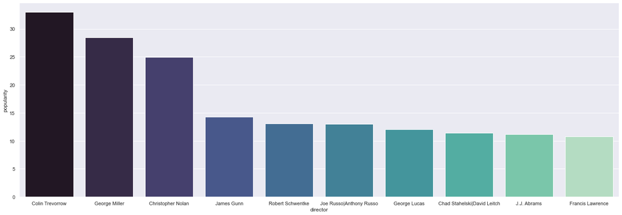

```python
sns.set(rc={'figure.figsize':(24,8)})

topdirectors(df, 'popularity' , top=10)
plt.show()
```

## Q3- Does the month affect revenue ?

We changed the format of 'release_date' column to datetime format, so we can extract months from the date

```python
#Changing the format of release_date to datetime format
df['release_date'] = pd.to_datetime(df['release_date'])
#Adding a new column with month

df['month'] = df['release_date'].dt.month
#Defining variable that group every month with revenue average
RevPerMonths = df.groupby('month')['revenue'].mean()
RevPerMonths
```

```
month
1     5.342218e+07
2     7.135161e+07
3     1.035897e+08
4     9.496919e+07
5     1.697212e+08
6     1.777592e+08
7     1.390053e+08
8     7.073754e+07
9     5.314429e+07
10    7.841869e+07
11    1.469099e+08
12    1.343913e+08
Name: revenue, dtype: float64
```

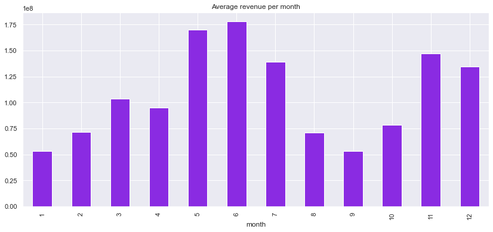

```python
RevPerMonths.plot(kind='bar',figsize = (14,6), color = 'blueviolet')
plt.title('Average revenue per month')
```

## Q4- What are the genres with highest number of movies ?

To fix the seperation problem in genres column we split each string by |

```python
gen = pd.Series((df['genres'].str.cat(sep = '|')).split('|')).value_counts(ascending=False)
gen
```

```
Drama              1753
Comedy             1357
Thriller           1203
Action             1085
Adventure           749
Romance             666
Crime               651
Science Fiction     519
Horror              463
Family              425
Fantasy             396
Mystery             344
Animation           201
Music               134
History             129
War                 119
Western              52
Documentary          31
Foreign              12
TV Movie              1
dtype: int64
```

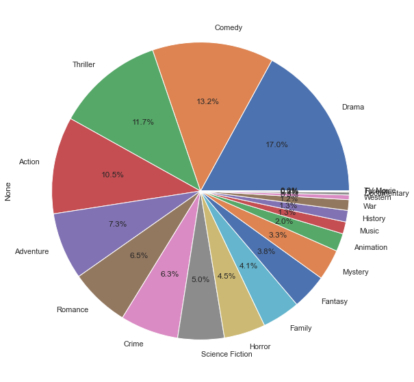

```python
#create pie chart
gen.plot(kind="pie",figsize = (10,10) ,autopct="%1.1f%%")
```

The highest genre in terms of moviea number are: 1- Drama 2- Comedy 3- Thriller 4- Action 5- Adventure

## Q5- Are the vote average increasing or decreasing overtime?

Here we grouped each year with it's vote average to see if it was increasing or decreasing overtime

```python
VoteAvgOT = df.groupby('release_year')['vote_average'].mean()
VoteAvgOT
```

```
release_year
1960    7.400000
1961    6.620000
1962    6.900000
1963    6.766667
1964    6.971429
1965    6.540000
1966    6.880000
1967    6.669231
1968    6.655556
1969    6.900000
1970    6.700000
1971    6.700000
1972    7.000000
1973    6.841667
```

[output cut: 43 more lines]

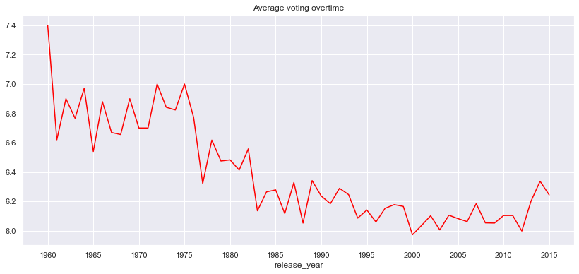

```python
VoteAvgOT.plot(xticks = np.arange(1960,2016,5) , color = 'red')
plt.title('Average voting overtime')
```

As we can see the vote average trend are decreasing over time , the average of 1960 movies is 7.4 while the average of 2015 movies is 6.2

## Q6- Does the budget affect the rating ?

to group the data by vote_average and budget we defined RBudget then sort it using .sort_values(), to sort it descending .

```python
RBudget = df.groupby('vote_average').max().budget
#To sort it by highest
RBudget = RBudget.sort_values(ascending=False)
```

[figure not shown]

```python
(RBudget).plot(kind='bar',figsize = (20,6))
plt.title('Average budget per rating ')
```

As we can see the movies with the highest budget are average movies in terms of vote average (between 6.3 - 6.4) , and the movies with high ratings has an average budget and some movies with +8.0 vote average are on the bottom of the budget list

## Q7 - Number of movies released over the years ?

Here we plot 1-Dimensional distribution for Release_year column.

[figure not shown]

```python
MR = df.release_year
MR.plot(kind='hist',figsize = (14,6), color = 'blueviolet')
```

# Conclusion

## Limitation

- The null values in our data affected the result , we had 10866 rows in the begining and after cleanining the data we has less then 4000 rows.
- Duplicates also affected the result.
- Zero values like in the budget and revenue affected the result.
- Some ivalid values in data, like genres each movie has multiple genre tags but are genres are not seperated probably

## Referencess

- https://matplotlib.org/stable/gallery/index.html
- http://seaborn.pydata.org/examples/index.html